# 📊 Data Visualization - Olympics

### 🏐 Voleibol

```python
# Definindo esporte a ser analisado
analyzed_sport = 'Volleyball'
```

#### Análise por Atleta

```python
# Filtrando o DataFrame para plotar o gráfico do esporte analisado
df_brazil_for_sport_plotting = df_brazil_for_plotting[df_brazil_for_plotting['Sport'] == analyzed_sport]

# Plotando gráfico
fig = px.strip(data_frame=df_brazil_for_sport_plotting, x='Medalha', y='Height',
               color='Medalha',
               facet_col='Sex',
               hover_data=athletes_chosen_columns_for_hover,
               category_orders=category_orders,
               color_discrete_map=color_info,
               title='🏐 Altura dos Atletas x Performance em Medalhas')

# Customizando gráfico
fig.update_traces(hovertemplate='%{customdata[1]}<br>'
                                'Altura: %{y}cm.<br>'
                                'Competindo em: %{customdata[10]}, %{customdata[8]}.<extra></extra>');

fig.update_layout(yaxis=dict(tickfont_size=10,
                             title=dict(font_size=12,
                                        text='Altura (cm)')));

fig.update_xaxes(matches=None,
                 tickfont_size=10,
                 title=dict(font_size=12,
                            text='Performance (Medalha)'));

fig.for_each_annotation(lambda annotation: annotation.update(text='👨 Masculino', font_size=13)
                        if annotation.text.split("=")[-1] == 'M'
                        else annotation.update(text='🙎‍♀️ Feminino', font_size=13));
```

```python
# Apresentando gráfico
fig.show()
```

[interactive chart not shown]

#### Análise por Time

```python
# Filtrando o DataFrame para plotar o gráfico do esporte analisado por equipe
df_brazil_for_sport_plotting_grouped = df_brazil_for_plotting_grouped[df_brazil_for_plotting_grouped['Sport']
                                                                      == analyzed_sport]

# Plotando gráfico
fig = px.strip(data_frame=df_brazil_for_sport_plotting_grouped, x='Medalha', y='Height',
               color='Medalha',
               facet_col='Sex',
               hover_data=teams_chosen_columns_for_hover,
               category_orders=category_orders,
               color_discrete_map=color_info,
               title='🏐 Altura Média do Time x Performance em Medalhas')

# Customizando gráfico
fig.update_traces(hovertemplate='Jogos: %{customdata[1]}, %{customdata[0]}.<br>'
                                'Altura média do time: %{y:.0f}cm.<br><extra></extra>');

fig.update_layout(yaxis=dict(tickfont_size=10,
                             title=dict(font_size=12,
                                        text='Altura Média (cm)')));

fig.update_xaxes(matches=None,
                 tickfont_size=10,
                 title=dict(font_size=12,
                            text='Performance (Medalha)'));

fig.for_each_annotation(lambda annotation: annotation.update(text='👨 Masculino', font_size=13)
                        if annotation.text.split("=")[-1] == 'M'
                        else annotation.update(text='🙎‍♀️ Feminino', font_size=13));
```

```python
# Apresentando gráfico
fig.show()
```

[interactive chart not shown]

#### Conclusão

Aqui, principalmente na visualização de altura média do time, notamos que há uma boa correlação entre altura e desempenho para ambas as categorias.

Na visualização de atletas, os dados estão mais distribuídos. Porém, é importante levar em consideração que há atletas de posições naturalmente mais baixas (levantador e líbero). Mesmo assim, notamos uma correlação.

### 📝 Considerações Finais

Cada esporte tem suas peculiaridades, que são dinâmicas e evoluem no tempo. Encontramos comportamentos variados em cada visualização.

Para conclusões mais robustas, os dados de ranking final do atleta (incluindo quarto, quinto,..., último lugar) proveriam uma base sólida para melhores conclusões.

## 🏅Medalhas por Esporte

**3. Vamos analisar agora as medalhas que nossos atletas trouxeram para casa.**

Crie uma visualização de sua preferência para mostrar, por esporte, a proporção de medalhas de ouro, prata e bronze que nosso país já consquistou.

**Facilitador:** Se preferir, mostre as proporções apenas para os 6 esportes que tiveram mais medalhas.

*DICA:* Cuidado! Esportes em equipe dão medalhas a todos os jogadores, mas só contabilizam uma vez!

```python
# Criando uma cópia do DataFrame para plotagem do gráfico de medalhas
df_brazil_medal_plot = df_brazil.copy()

# Agrupando o DataFrame para obter 01 registro por medalha conquistada
df_brazil_medal_plot = df_brazil_medal_plot.groupby(by=['Medal', 'Sport',
                                                        'Event', 'Year'],
                                                    as_index=False).count()

# Agrupando o DataFrame por Medalha e Esporte
df_brazil_medal_plot = df_brazil_medal_plot.groupby(by=['Medal', 'Sport'], as_index=False).count()

# Criando uma nova coluna em português para a plotagem das medalhas no gráfico
values_info = {'Gold': 'Ouro',
               'Silver': 'Prata',
               'Bronze': 'Bronze'}

df_brazil_medal_plot['Medalha'] = df_brazil_medal_plot['Medal'].map(values_info)

# Criando uma nova coluna em português para a plotagem dos esportes nos gráficos
sports_info = {'Sailing': 'Vela',
               'Athletics': 'Atletismo',
               'Volleyball': 'Voleibol',
               'Judo': 'Judô',
               'Beach Volleyball': 'Voleibol de Praia',
               'Boxing': 'Boxe',
               'Equestrianism' : 'Equitação',
               'Football': 'Futebo',
               'Gymnastics': 'Ginástica',
               'Shooting': ' Tiro',
               'Swimming': 'Natação',
               'Canoeing': 'Canoagem',
               'Basketball': 'Basquetebol',
               'Taekwondo': 'Taekwondo',
               'Modern Pentathlon': 'Pentlato Moderno'}

df_brazil_medal_plot['Esporte'] = df_brazil_medal_plot['Sport'].map(sports_info)

# Definindo a sequência de ordenação das colunas
df_brazil_medal_plot['Medalha'] = pd.Categorical(values=df_brazil_medal_plot['Medalha'],
                                categories=('Bronze', 'Prata', 'Ouro'),
                                ordered=True)

df_brazil_medal_plot.sort_values(['Medalha', 'Event'], ascending=False, inplace=True)

# Definições de apresentação
color_info = {'Bronze': 'lightsalmon',
              'Prata': 'grey',
              'Ouro': 'gold'}

# Plotando gráfico
fig = px.bar(data_frame=df_brazil_medal_plot, x='Event', y='Esporte', color='Medalha',
             color_discrete_map=color_info,
             orientation='h', text_auto=True,
             title='🏅 Medalhas Olímpicas por Esporte')

# Customizando gráfico
fig.update_traces(textposition='inside',
                  insidetextanchor='middle',
                  textangle=0);

fig.update_layout(yaxis=dict(autorange='reversed',
                             title_text=None,
                             ticks=''),
                  xaxis_visible=False,
                  hovermode=False);
```

```python
# Apresentando gráfico
fig.show()
```

[interactive chart not shown]

## 📈 Série Temporal de Medalhas

**4. Para finalizar a história do Brasil, vamos ver a série temporal de medalhas brasileiras.**

Crie um gráfico de sua escolha, que mostre o total de medalhas de ouro, prata e bronze, por edição da olimpíada (em ordem cronológica).

*DICA:* Mais uma vez, tome cuidado com os esportes em grupo - os contabilize apenas uma vez!

```python
# Determinando o país a ser analisado pelo NOC
chosen_country = 'BRA'

# Determinando se as Olímpiadas de Inverno serão consideradas
include_winter = False

# Determinando os passos no eixo X
dtick='M24'

# Aplicando os filtros
df_time_plot = df[df['NOC'] == chosen_country].copy()

if not include_winter:
    df_time_plot = df_time_plot[df_time_plot['Season'] != 'Winter'].copy()
    dtick='M48'

# Criando uma nova coluna em português para a contagem das medalhas
values_info = {'Gold': 'Ouro',
               'Silver': 'Prata',
               'Bronze': 'Bronze',
               np.nan: 'Sem Medalha'}

df_time_plot['Medalha'] = df_time_plot['Medal'].map(values_info)

# Definições de apresentação
color_info = {'Sem Medalha': 'seagreen',
              'Bronze': 'lightsalmon',
              'Prata': 'grey',
              'Ouro': 'gold'}

category_orders = {"Medalha": ["Sem Medalha", "Bronze", "Prata", "Ouro"]}

# Agrupando o DataFrame para contar somente 01 medalha por time
df_time_plot = df_time_plot.groupby(by=['Year', 'Medalha', 'Event'], as_index=False).count()
df_time_plot = df_time_plot.groupby(by=['Year', 'Medalha'], as_index=False).count()

# Pivotando o DataFrame para contabilizar as medalhas em colunas
df_time_plot = df_time_plot.pivot(index='Year', columns='Medalha')['Event']
df_time_plot.fillna(0, inplace=True)

# Plotando gráfico
fig = px.line(data_frame=df_time_plot, x=df_time_plot.index, y=['Ouro', 'Prata', 'Bronze'],
              color_discrete_map=color_info, markers=True,
              title='🇧🇷 Linha do Tempo das Medalhas do Brasil')

# Customizando gráfico
fig.update_traces(hovertemplate='Ano: %{x|%Y}.<br>'
                                'Medalhas: %{y}.<br>',
                  marker_size=8);

fig.update_layout(legend_title_text='Medalha');

fig.update_yaxes(tickfont_size=10,
                 title=dict(font_size=12,
                            text='Quantidade de Medalhas'),
                 rangemode='tozero');

fig.update_xaxes(tickfont_size=10,
                 title=dict(font_size=12,
                            text='Ano'),
                 type='date',
                 dtick='M48',
                 tickangle=45);
```

```python
# Apresentando gráfico
fig.show()
```

[interactive chart not shown]

## 🔬 Análise Visual

**5. Agora é com vocês!**

Escolha uma análise visual que julga interessante de fazer neste conjunto de dados, faça o(s) gráficos(s) necessários e comente os resultados.

### Análise das 10 provas mais tradicionais do Brasil

```python
def traducao(x):
    '''Função responsável por traduzir os nomes das 10 provas mais tradicionais do Brasil.
        Arg (x) : str com nome em inglês.
        Return : str com nome em português.'''

    tradutor = dict(zip(["Volleyball Men's Volleyball","Beach Volleyball Men's Beach Volleyball","Athletics Men's Triple Jump",
                         "Sailing Mixed One Person Dinghy","Volleyball Women's Volleyball","Beach Volleyball Women's Beach Volleyball",
                         "Football Men's Football","Judo Men's Half-Heavyweight", "Sailing Men's Two Person Keelboat","Athletics Men's 800 metres"],
                        ["Vôleibol Masculino","Vôleibol de Praia Masculino","Salto Triplo Masculino","Vela Jangada Mista de Uma Pessoa",
                         "Vôleibol Feminino","Vôleibol de Praia Feminino","Futebol Masculino","Judo Masculino Meio-Pesado",
                         "Dupla Masculina de Velas Keelboat","800 Metros Masculino"]))
    if x in tradutor:
        return tradutor[x]
    else:
        return x
```

```python
# Criando uma cópia do DataFrame para plotagem do gráfico de medalhas por provas

br = df[df['NOC']=='BRA'].copy()

tirando_medalhas_repetidas= br[['Medal','Sport','Year','Event']].copy()

tirando_medalhas_repetidas.drop_duplicates(inplace=True)

tirando_medalhas_repetidas.Event = tirando_medalhas_repetidas.Event.apply(traducao)

medalhas=pd.get_dummies(tirando_medalhas_repetidas.Medal)

tirando_medalhas_repetidas=pd.merge(tirando_medalhas_repetidas,medalhas,on=tirando_medalhas_repetidas.index)

top10eventos= tirando_medalhas_repetidas.groupby('Event')[['Gold','Silver','Bronze']].sum().sort_values(['Gold','Silver','Bronze'],ascending=False).head(10)
```

```python
color_info = {'Bronze': 'lightsalmon',
              'Silver': 'grey',
              'Gold': 'gold'}

fig = px.funnel(top10eventos,color_discrete_map=color_info,title='🇧🇷 Dez Provas Mais Tradicionais do Brasil')
fig.update_yaxes(title='Provas');
fig.update_layout(legend=dict(title='Medalha'));
```

```python
# Apresentando o gráfico
fig.show()
```

[interactive chart not shown]

#### Conclusão

Observa-se que apesar das modalidade das Velas ser o esporte com mais ouro como demonstrado na questão 3 ao separamos por evento temos que o vôleibol masculino tem a maior quantidade de 1° colocações;.

Podemos destacar também que o atletismo (O segundo da questão 3) possui 2 provas dentre as 10 assim como a vela.

Podemos destacar que as modalidades de vôleibol são as unicas com representação exclusivamente feminina dentro o top 10.

### Análise da Evolução de Altura nos pódios de Basquetebol

```python
df_copy = df.copy()
df_copy['Medal'].fillna('others_athlete', inplace= True)
df_podium = df_copy[(pd.notnull(df_copy['Medal'])) &  (df_copy['Event'] == "Basketball Men's Basketball")]

means = df_podium.groupby(['Year', 'Medal'], as_index=False).mean()
```

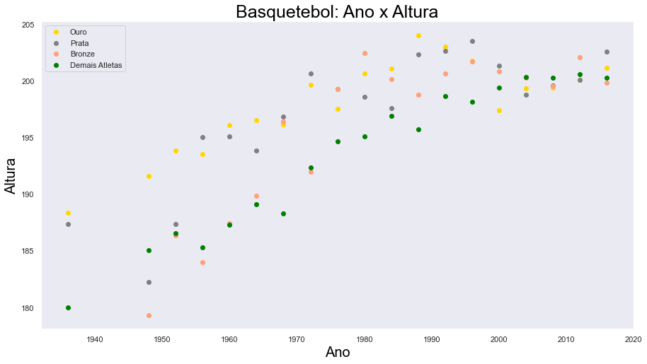

```python
fig, ax = plt.subplots(figsize=(15,8))

gold = means[means['Medal']=='Gold'].copy()
silver = means[means['Medal']=='Silver'].copy()
bronze = means[means['Medal']=='Bronze'].copy()
others = means[means['Medal']== 'others_athlete'].copy()

ax.scatter(x ='Year', y= 'Height', data= gold, c= 'gold', label= 'Ouro')
ax.scatter(x ='Year', y= 'Height', data= silver, c= 'grey', label= 'Prata')
ax.scatter(x ='Year', y= 'Height', data= bronze, c= 'lightsalmon', label= 'Bronze')
ax.scatter(x ='Year', y= 'Height', data= others, c= 'green', label= 'Demais Atletas')

ax.legend()
ax.set_title('Basquetebol: Ano x Altura', fontname='Arial', size=25, color='black')
ax.set_xlabel('Ano', fontname='Arial', size=20, color='black')
ax.set_ylabel('Altura' , fontname='Arial', size=20, color='black')

sns.set_style('dark')
sns.set_context('notebook')
plt.show()
```

#### Conclusão

É possivel notar no gráfico acima formações de linhas de tendência, embora careça de medidas de dispersão.